# Synthetic Control Method using R

Adrien VALLETTE et Lorelei DURAND

17/04/2021

Importation des librairies

```r
library(Synth)
library(SCtools)
library(stringr)
```

## Données

Après avoir importer la base, on observe sa forme puis on met la variable “TIME” au format numérique.

```r
data <- read.csv("dfR_complete_netexp.csv")
summary(data)
```

```
##      index        LOCATION             TIME                PIB
##  Min.   :   0   Length:2525        Length:2525        Min.   :-0.006089
##  1st Qu.: 631   Class :character   Class :character   1st Qu.: 0.176063
##  Median :1262   Mode  :character   Mode  :character   Median : 0.361756
##  Mean   :1262                                         Mean   : 0.431926
##  3rd Qu.:1893                                         3rd Qu.: 0.558003
##  Max.   :2524                                         Max.   : 2.909356
##      Actifs            Emplois            Chomage         ID_country
##  Min.   :-0.02426   Min.   :-0.04829   Min.   : 1.757   Min.   : 1
##  1st Qu.: 0.03819   1st Qu.: 0.05042   1st Qu.: 4.450   1st Qu.: 7
##  Median : 0.09517   Median : 0.11734   Median : 6.106   Median :13
##  Mean   : 0.13932   Mean   : 0.15912   Mean   : 6.971   Mean   :13
##  3rd Qu.: 0.19349   3rd Qu.: 0.22697   3rd Qu.: 8.441   3rd Qu.:19
##  Max.   : 0.70034   Max.   : 0.76071   Max.   :26.206   Max.   :25
##   Conso_share      Invest_share    NExport_share         Labor_prod
##  Min.   :0.2984   Min.   :0.1281   Min.   :-0.193035   Min.   :-0.079753
##  1st Qu.:0.4976   1st Qu.:0.2032   1st Qu.:-0.008517   1st Qu.:-0.001318
##  Median :0.5430   Median :0.2230   Median : 0.023169   Median : 0.002588
##  Mean   :0.5371   Mean   :0.2259   Mean   : 0.036723   Mean   : 0.003109
##  3rd Qu.:0.5786   3rd Qu.:0.2416   3rd Qu.: 0.063344   3rd Qu.: 0.007558
##  Max.   :0.6866   Max.   :0.3944   Max.   : 0.397196   Max.   : 0.196158
```

```r
data$TIME <- str_replace_all(data$TIME, "[:punct:]Q1", ".00" )
data$TIME <- str_replace_all(data$TIME, "[:punct:]Q2", ".25" )
data$TIME <- str_replace_all(data$TIME, "[:punct:]Q3", ".50" )
data$TIME <- str_replace_all(data$TIME, "[:punct:]Q4", ".75" )
data <- transform(data, TIME = as.numeric(TIME))
data$LOCATION <- as.character(data$LOCATION)
summary(data)
```

```
##      index        LOCATION              TIME           PIB
##  Min.   :   0   Length:2525        Min.   :1995   Min.   :-0.006089
##  1st Qu.: 631   Class :character   1st Qu.:2001   1st Qu.: 0.176063
##  Median :1262   Mode  :character   Median :2008   Median : 0.361756
##  Mean   :1262                      Mean   :2008   Mean   : 0.431926
##  3rd Qu.:1893                      3rd Qu.:2014   3rd Qu.: 0.558003
##  Max.   :2524                      Max.   :2020   Max.   : 2.909356
##      Actifs            Emplois            Chomage         ID_country
##  Min.   :-0.02426   Min.   :-0.04829   Min.   : 1.757   Min.   : 1
##  1st Qu.: 0.03819   1st Qu.: 0.05042   1st Qu.: 4.450   1st Qu.: 7
##  Median : 0.09517   Median : 0.11734   Median : 6.106   Median :13
##  Mean   : 0.13932   Mean   : 0.15912   Mean   : 6.971   Mean   :13
##  3rd Qu.: 0.19349   3rd Qu.: 0.22697   3rd Qu.: 8.441   3rd Qu.:19
##  Max.   : 0.70034   Max.   : 0.76071   Max.   :26.206   Max.   :25
##   Conso_share      Invest_share    NExport_share         Labor_prod
##  Min.   :0.2984   Min.   :0.1281   Min.   :-0.193035   Min.   :-0.079753
##  1st Qu.:0.4976   1st Qu.:0.2032   1st Qu.:-0.008517   1st Qu.:-0.001318
##  Median :0.5430   Median :0.2230   Median : 0.023169   Median : 0.002588
##  Mean   :0.5371   Mean   :0.2259   Mean   : 0.036723   Mean   : 0.003109
##  3rd Qu.:0.5786   3rd Qu.:0.2416   3rd Qu.: 0.063344   3rd Qu.: 0.007558
##  Max.   :0.6866   Max.   :0.3944   Max.   : 0.397196   Max.   : 0.196158
```

On crée une liste de prédicteurs afin de réaliser la minimisation sur les séries temporelles souhaitées (PIB, Emplois et Actifs) en plus de covariables (moyenne entre 2015Q3 et 2016Q3 du taux de chômage, de la croissance de la productivité du travail, de la part de la consommation, de l’investissement et des exportations dans le PIB).

```r
list_predictor <- rep(list(list()), 261)

#PIB
for (i in 1:87) {
  list_predictor[[i]] <- append(list_predictor[[i]], list('PIB', data$TIME[i+1], 'mean'))
}
#Emplois
for (j in 1:87) {
  list_predictor[[j+87]]  <- append(list_predictor[[j+87]], list('Emplois', data$TIME[j+1], 'mean'))
}
#Actifs
for (k in 1:87) {
  list_predictor[[k+174]]  <- append(list_predictor[[k+174]], list('Actifs', data$TIME[k+1], 'mean'))
}
```

## Modélisation

### Modèle baseline

On utilise d’abord la fonction dataprep() du package “Synth”, qui va préparer les vecteurs et matrices utilisées pour trouver la pondération. x1 est le vecteur pour l’unité traité (les Etats-Unis) des 3 séries temporelles et des 5 covariables, X0, la matrice équivalente pour les unités de contrôle (le donor pool), Z1 le vecteur de la variable d’intérêt (ici le taux de chômage) pour l’unité traité et Z0 la matrice de la variable d’intérêt pour chacun des pays du donor pool.

```r
dataprep.out <- dataprep(
  foo = data,
  predictors = c("Chomage", "Conso_share", "Invest_share", 'NExport_share', 'Labor_prod'),
  predictors.op = "mean",
  time.predictors.prior = 2015.50:2016.50,
  special.predictors = list_predictor,
  dependent = "Chomage",
  unit.variable = "ID_country",
  unit.names.variable = "LOCATION",
  time.variable = "TIME",
  treatment.identifier = 25,
  controls.identifier = 1:24,
  time.optimize.ssr = 1995.00:2016.50,
  time.plot = 1995.00:2020.00)

#dataprep.out$X1
#dataprep.out$X0
#dataprep.out$Z0
dataprep.out$Z1
```

```
##            25
## 1995 5.479974
## 1996 5.547865
## 1997 5.226836
## 1998 4.641226
## 1999 4.288457
## 2000 4.049799
## 2001 4.230631
## 2002 5.704395
## 2003 5.872725
## 2004 5.681790
## 2005 5.283463
## 2006 4.720281
## 2007 4.523954
## 2008 4.983276
## 2009 8.291980
## 2010 9.837097
## 2011 9.039845
## 2012 8.262811
## 2013 7.747597
## 2014 6.625284
## 2015 5.531507
## 2016 4.925497
```

Résolution du problème de minisation à l’aide de la fonction synth() du package “Synth”. Elle nous donne en sortie les valeurs prédites par le contrôle synthétique pour chacune des variables de la minimisation, la pondération W du contrôle synthétique et la pondération V des variables.

```r
synth.tables <- synth.tab(dataprep.res = dataprep.out, synth.res = synth.out)
gaps <- dataprep.out$Y1plot - (dataprep.out$Y0plot %*% synth.out$solution.w)

head(synth.tables$tab.pred, 5)
```

```
##               Treated Synthetic Sample Mean
## Chomage         5.006     5.313       7.302
## Conso_share     0.679     0.521       0.520
## Invest_share    0.203     0.218       0.220
## NExport_share  -0.028     0.062       0.056
## Labor_prod      0.001     0.004       0.002
```

```r
head(synth.tables$tab.v, 5)
```

```
##               v.weights
## Chomage       0.074
## Conso_share   0
## Invest_share  0.001
## NExport_share 0.001
## Labor_prod    0
```

```r
synth.tables$tab.w
```

```
##    w.weights unit.names unit.numbers
## 1      0.000        AUS            1
## 2      0.000        AUT            2
## 3      0.000        BEL            3
## 4      0.079        CAN            4
## 5      0.000        CHE            5
## 6      0.000        DEU            6
## 7      0.000        DNK            7
## 8      0.000        ESP            8
## 9      0.000        FIN            9
## 10     0.000        FRA           10
## 11     0.000        GBR           11
## 12     0.133        HUN           12
## 13     0.099        IRL           13
## 14     0.312        ISL           14
## 15     0.000        ITA           15
## 16     0.283        JPN           16
## 17     0.000        KOR           17
## 18     0.000        LUX           18
## 19     0.000        NLD           19
## 20     0.000        NOR           20
## 21     0.000        NZL           21
## 22     0.094        PRT           22
## 23     0.000        SVK           23
## 24     0.000        SWE           24
```

### Graphique du modèle baseline

Pour le taux de chômage, le PIB, l’emploi et les actifs, on trace les courbes obtenus pour les Etats-Unis et le contrôle synthétique, l’intervalle de confiance étant obtenu par + ou - l’écart-type de la différence entre les vraies valeurs et celles prédites sur la période pré-traitement.

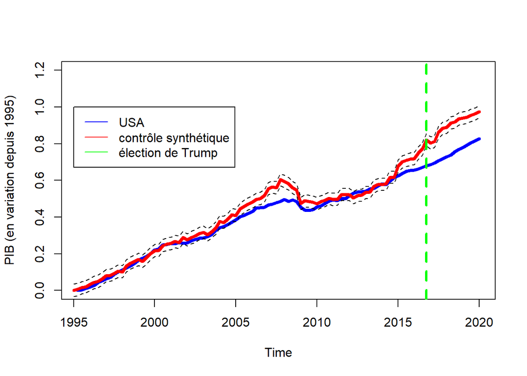

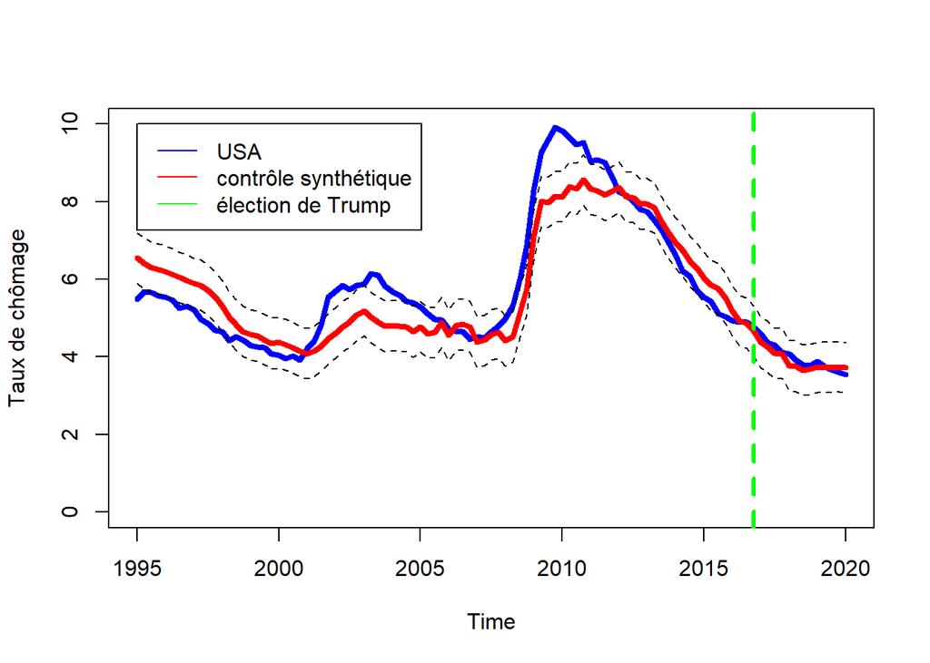

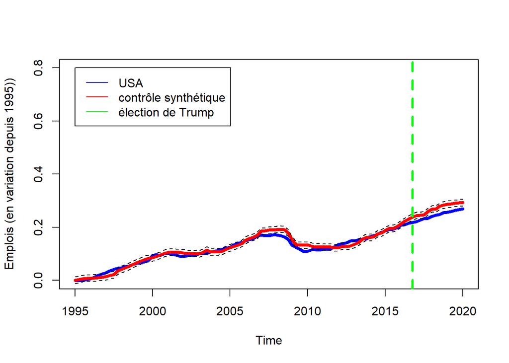

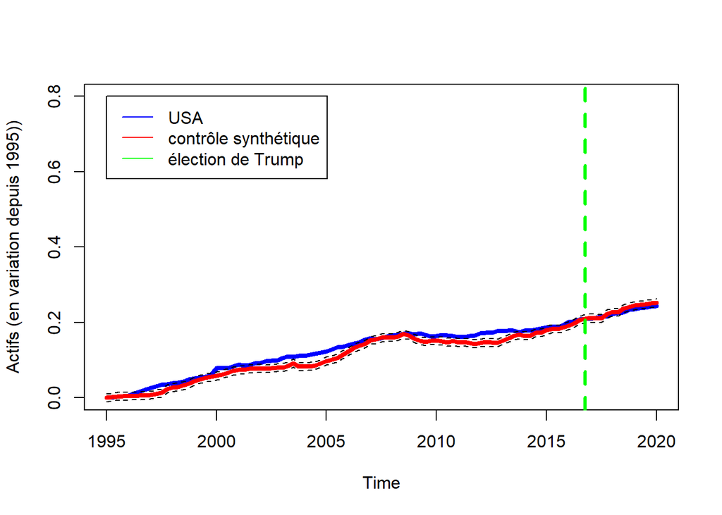

## Test de robustesse du modèle baseline

Pour vérifier la solidité de notre modèle, on peut réaliser différents tests. Tout d’abord, le test du “leave-one-out” afin de vérifier que la qualité du contrôle synthétique n’est pas trop dépendant d’un pays du donor pool. Pour cela, on refait tourner le modèle en excluant tour à tour, les différents pays ayant obtenus une pondération importante dans le modèle baseline. On voit avec le graphique que la qualité du fit et la prédiction reste proche, même en excluant les pays qui étaient importants dans le modèle baseline.

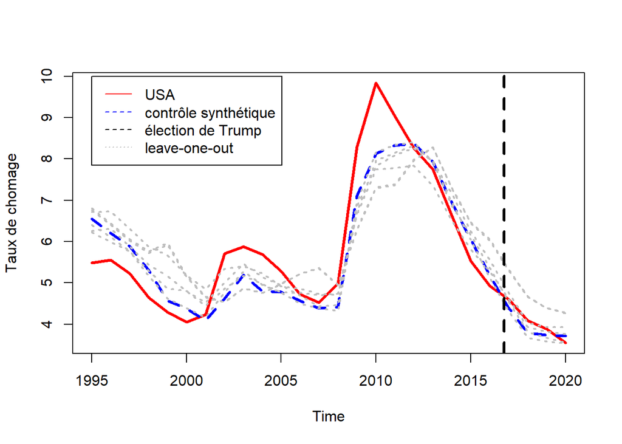

```r
country <- c(4, 12, 13, 14, 16, 22)
y0plot1 <- dataprep.out$Y0plot %*% synth.out$solution.w
d <- as.data.frame(y0plot1)

for (i in country) {
  dp.out <- dataprep(
    foo = data,
    predictors = c("Chomage", "Conso_share", "Invest_share", 'NExport_share', 'Labor_prod'),
    predictors.op = "mean",
    time.predictors.prior = 2015.50:2016.50,
    special.predictors = list_predictor,
    dependent = "Chomage",
    unit.variable = "ID_country",
    unit.names.variable = "LOCATION",
    time.variable = "TIME",
    treatment.identifier = 25,
    controls.identifier = c(1:(i-1),(i+1):24),
    time.optimize.ssr = 1995.00:2016.50,
    time.plot = 1995.00:2020.00)
  s.out <- synth(data.prep.obj = dp.out, method = "BFGS")
  y0plot <- dp.out$Y0plot %*% s.out$solution.w
  d[ , ncol(d) + 1] <- y0plot                  # Append new column
  colnames(d)[ncol(d)] <- paste0("y0plot", i)  # Rename column name
}

plot(dataprep.out$tag$time.plot, dataprep.out$Y1plot, col = 'red', type = 'l',lwd=3, lty=1, xlab = 'Time', ylab = 'Taux de chomage')
lines(dataprep.out$tag$time.plot, d$w.weight, col = 'blue', type = 'l',lwd=3, lty=2)
lines(dataprep.out$tag$time.plot, d$y0plot4, col = 'grey', type = 'l',lwd=2, lty=3)
lines(dataprep.out$tag$time.plot, d$y0plot12, col = 'grey', type = 'l',lwd=2, lty=3)
lines(dataprep.out$tag$time.plot, d$y0plot13, col = 'grey', type = 'l',lwd=2, lty=3)
lines(dataprep.out$tag$time.plot, d$y0plot14, col = 'grey', type = 'l',lwd=2, lty=3)
lines(dataprep.out$tag$time.plot, d$y0plot16, col = 'grey', type = 'l',lwd=2, lty=3)
lines(dataprep.out$tag$time.plot, d$y0plot22, col = 'grey', type = 'l',lwd=2, lty=3)
abline(v = 2016.75, col="black", lwd=3, lty=2)
legend(1995, 10, legend=c("USA", "contrôle synthétique", "élection de Trump", "leave-one-out"),
       col=c("red", "blue", "black", "grey"), lty=c(1,2,2,3,3,3))
```

Un autre test que l’on peut mener concerne les “space placebo” (avec le package “SCtools”), c’est à dire qu’on regarde ce qu’il se passe si l’on choisit comme unité traité chacun des pays du donor pool au lieu des Etats-Unis. Si l’effet de Trump est significatif, on devrait observer une absence de réaction lorsqu’on place le choc dans un autre pays (ie une moyenne des erreurs post-traitement faible comparé à la celle de la période pré-traitement). La p-value obtenue s’interprète comme la probabilité d’obtenir un tel choc en prenant un pays du donor pool au hasard: si elle est faible, c’est qu’il y a bien un “effet Trump”, si elle est élevé (le ratio MPSE post/pre des Etats-Unis est fiable). On fait aussi le graphique de la différence entre le taux de chômage et sa prédiction par le contrôle synthétique pour chacun des pays.

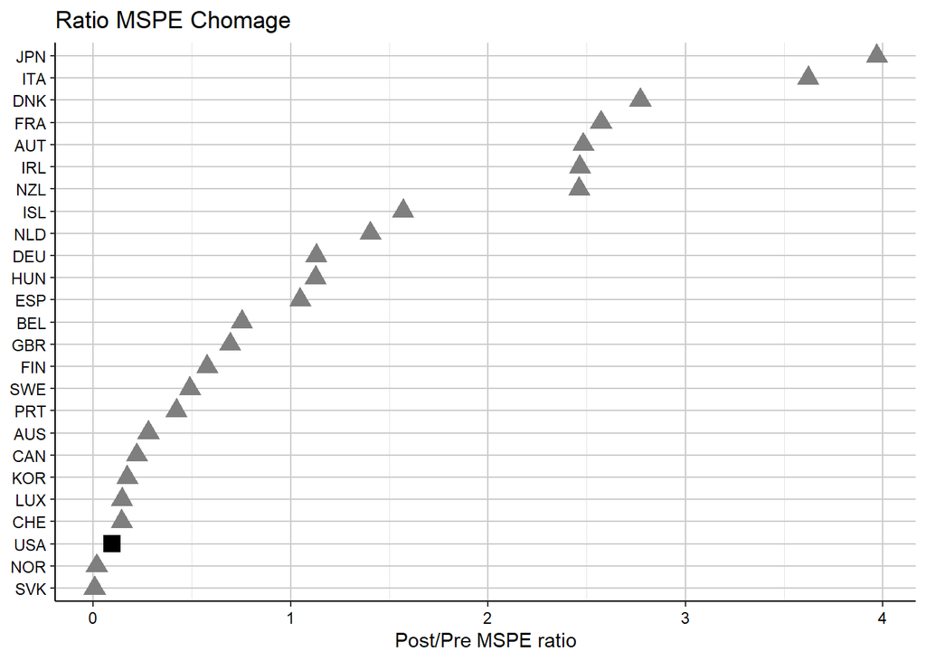

```r
tdf <- generate.placebos(dataprep.out,synth.out, Sigf.ipop = 2, strategy = "multiprocess")

mspe.plot(
  tdf,
  discard.extreme = FALSE,
  mspe.limit = 20,
  plot.hist = FALSE,
  title = "Ratio MSPE Chomage",
  xlab = "Post/Pre MSPE ratio",
  ylab = NULL
)
```

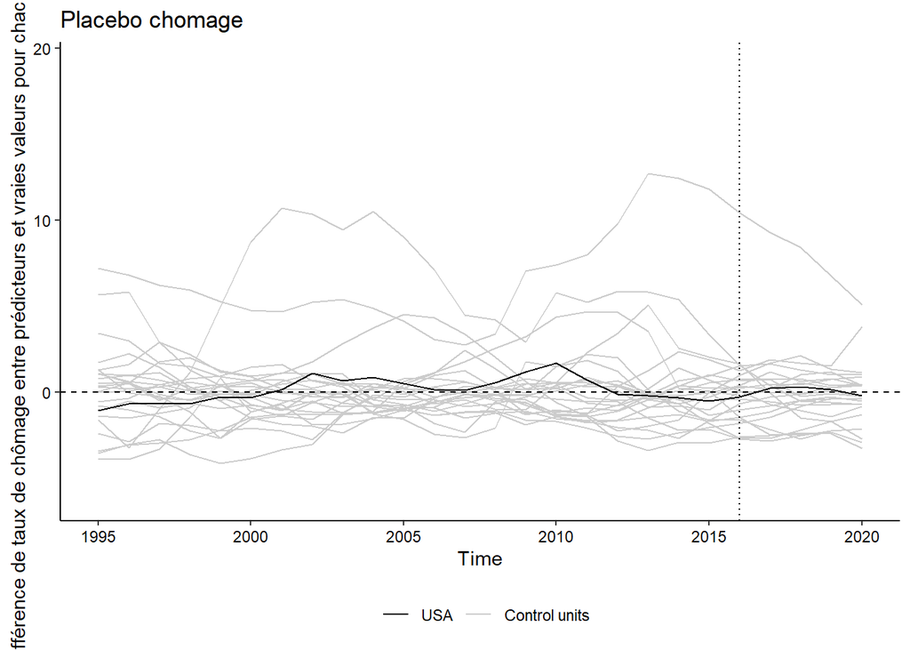

```r
ratio <- mspe.test(tdf)
ratio$p.val

plot_placebos(
  tdf = tdf,
  discard.extreme = FALSE,
  mspe.limit = 20,
  xlab = 'Time',
  ylab = 'Différence de taux de chômage entre prédicteurs et vraies valeurs pour chacun des pays',
  title = "Placebo chomage",
  alpha.placebos = 1,
)
```

```r
ratio$p.val
```

```
## [1] 0.92
```

De la même façon qu’on a réalisé des tests dit “space placebos”, on peut réaliser des tests dit “time placebos” en plaçant le choc non pas en 2016Q4 mais à une autre période. Ce test permet de contrôler la qualité du fit: si on reproduit bien les données après un choc placebo en 2011 (par exemple), c’est que le contrôle synthétique est un bon modèle. En outre, on s’attend à ne pas observer d’effet particulier après le faux choc (Trump n’a pas été élu en 2011, il ne devrait donc pas y avoir de réaction).

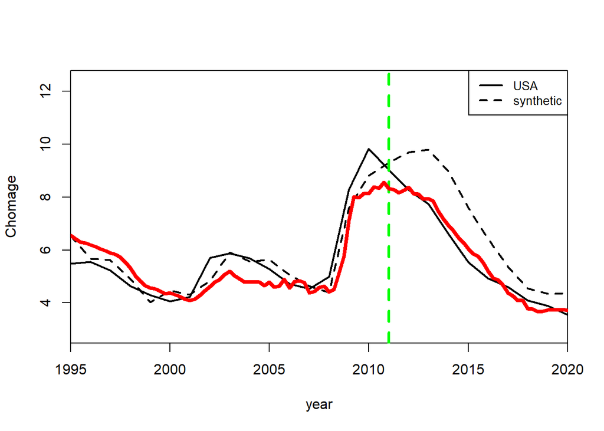

```r
list_pred_2011 <- rep(list(list()), 189)

#PIB
for (i in 1:63) {
  list_pred_2011[[i]] <- append(list_pred_2011[[i]], list('Chomage', data$TIME[i+1], 'mean'))
}
#Emplois
for (j in 1:63) {
  list_pred_2011[[j+63]]  <- append(list_pred_2011[[j+63]], list('Emplois', data$TIME[j+1], 'mean'))
}
#Actifs
for (k in 1:63) {
  list_pred_2011[[k+126]]  <- append(list_pred_2011[[k+126]], list('Actifs', data$TIME[k+1], 'mean'))
}

dp2011.out <- dataprep(
  foo = data,
  predictors = c("Chomage", "Conso_share", "Invest_share", 'NExport_share', 'Labor_prod'),
  predictors.op = "mean",
  time.predictors.prior = 2009.50:2010.75,
  special.predictors = list_pred_2011,
  dependent = "Chomage",
  unit.variable = "ID_country",
  unit.names.variable = "LOCATION",
  time.variable = "TIME",
  treatment.identifier = 25,
  controls.identifier = 1:24,
  time.optimize.ssr = 1995.00:2010.75,
  time.plot = 1995.00:2020.00)

start.time <- Sys.time()
synth2011.out <- synth(data.prep.obj = dp2011.out, method = "BFGS")
end.time <- Sys.time()
time.taken <- end.time - start.time
time.taken

synth2011.tables <- synth.tab(dataprep.res = dp2011.out, synth.res = synth2011.out)
synth2011.tables$tab.w

path.plot(synth.res = synth2011.out, dataprep.res = dp2011.out, Ylab = "Chomage", Xlab = "year", Legend = c("USA", "synthetic"), Legend.position = "topright")
abline(v = 2011, col="green", lwd=3, lty=2)
lines(data$TIME[1:101], graph_bl$sc_cho, col="red", type = "l", lty=1, lwd=4)
```

## Modèle cherchant à évaluer l’impact sur le PIB

On applique toutes les fonctions précédentes en inversant le rôle du chômage et du PIB de façon à ce que le PIB soit la variable centrale d’intérêt.

```r
list_pred_pib <- rep(list(list()), 261)

#Chomage
for (i in 1:87) {
  list_pred_pib[[i]] <- append(list_pred_pib[[i]], list('Chomage', data$TIME[i+1], 'mean'))
}
#Emplois
for (j in 1:87) {
  list_pred_pib[[j+87]]  <- append(list_pred_pib[[j+87]], list('Emplois', data$TIME[j+1], 'mean'))
}
#Actifs
for (k in 1:87) {
  list_pred_pib[[k+174]]  <- append(list_pred_pib[[k+174]], list('Actifs', data$TIME[k+1], 'mean'))
}
```

```r
dp_pib.out <- dataprep(
  foo = data,
  predictors = c("PIB", "Conso_share", "Invest_share", 'NExport_share', 'Labor_prod'),
  predictors.op = "mean",
  time.predictors.prior = 2015.50:2016.50,
  special.predictors = list_pred_pib,
  dependent = "PIB",
  unit.variable = "ID_country",
  unit.names.variable = "LOCATION",
  time.variable = "TIME",
  treatment.identifier = 25,
  controls.identifier = 1:24,
  time.optimize.ssr = 1995.00:2016.50,
  time.plot = 1995.00:2020.00)

#dp_pib.out$X1
#dp_pib.out$X0
#dp_pib.out$Z0
dp_pib.out$Z1
```

```
##              25
## 1995 0.00000000
## 1996 0.02601112
## 1997 0.07027390
## 1998 0.12223876
## 1999 0.17637631
## 2000 0.22577915
## 2001 0.25409109
## 2002 0.27062351
## 2003 0.29312532
## 2004 0.34878862
## 2005 0.40099590
## 2006 0.44798383
## 2007 0.46944719
## 2008 0.48633461
## 2009 0.43744800
## 2010 0.46203201
## 2011 0.49025840
## 2012 0.52977642
## 2013 0.55382371
## 2014 0.57646597
## 2015 0.63650670
## 2016 0.66198460
```

```r
s_pib.tables <- synth.tab(dataprep.res = dp_pib.out, synth.res = s_pib.out)
gaps <- dp_pib.out$Y1plot - (dp_pib.out$Y0plot %*% s_pib.out$solution.w)

head(s_pib.tables$tab.pred, 5)
```

```
##               Treated Synthetic Sample Mean
## PIB             0.667     0.662       0.685
## Conso_share     0.679     0.574       0.520
## Invest_share    0.203     0.212       0.220
## NExport_share  -0.028     0.004       0.056
## Labor_prod      0.001     0.002       0.002
```

```r
head(s_pib.tables$tab.v, 5)
```

```
##               v.weights
## PIB           0.004
## Conso_share   0.021
## Invest_share  0.004
## NExport_share 0.028
## Labor_prod    0.009
```

```r
s_pib.tables$tab.w
```

```
##    w.weights unit.names unit.numbers
## 1      0.000        AUS            1
## 2      0.000        AUT            2
## 3      0.000        BEL            3
## 4      0.297        CAN            4
## 5      0.000        CHE            5
## 6      0.000        DEU            6
## 7      0.000        DNK            7
## 8      0.000        ESP            8
## 9      0.000        FIN            9
## 10     0.000        FRA           10
## 11     0.375        GBR           11
## 12     0.000        HUN           12
## 13     0.030        IRL           13
## 14     0.008        ISL           14
## 15     0.000        ITA           15
## 16     0.002        JPN           16
## 17     0.042        KOR           17
## 18     0.000        LUX           18
## 19     0.000        NLD           19
## 20     0.198        NOR           20
## 21     0.001        NZL           21
## 22     0.046        PRT           22
## 23     0.000        SVK           23
## 24     0.000        SWE           24
```

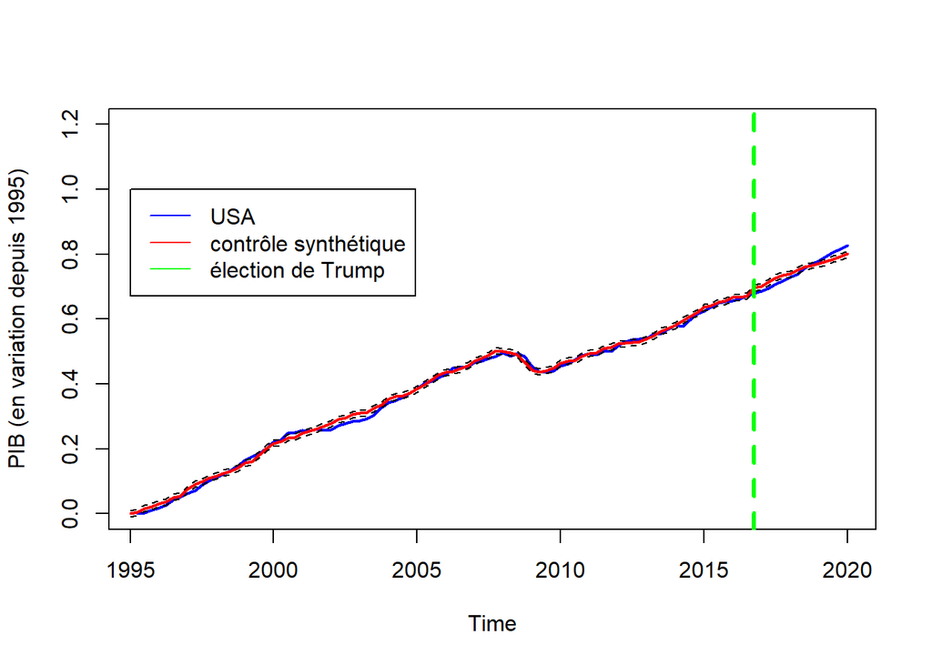

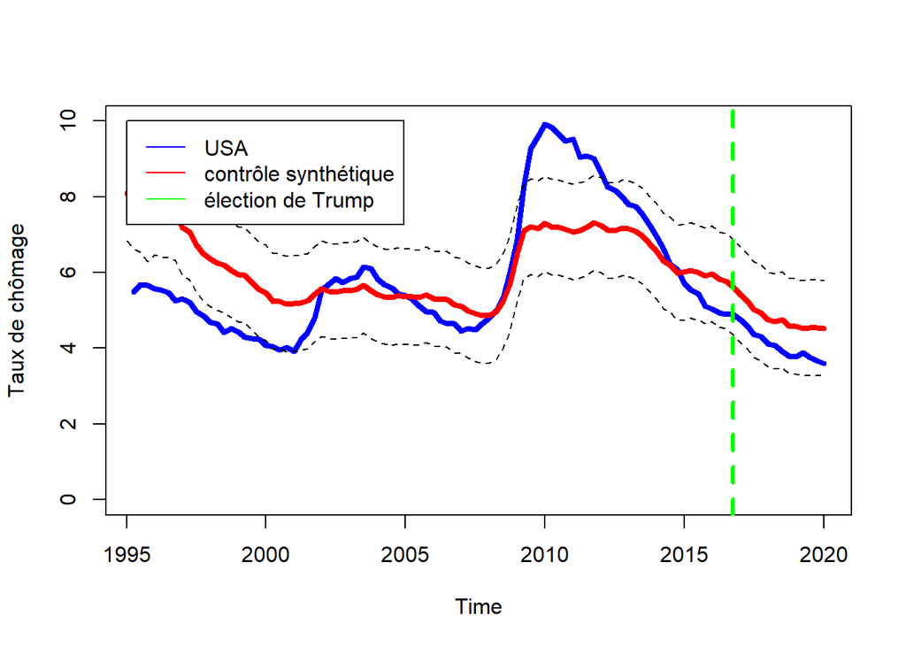

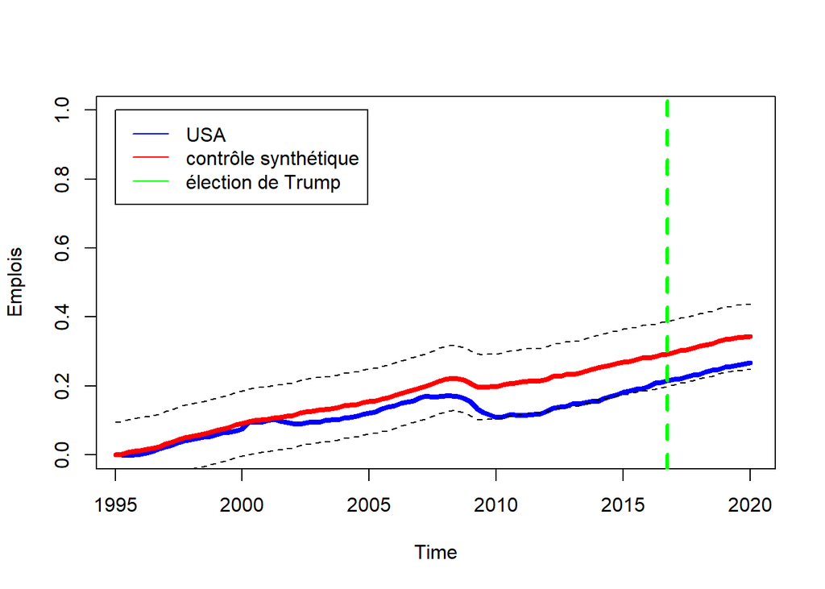

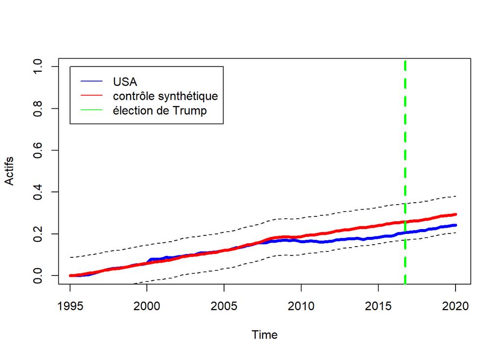

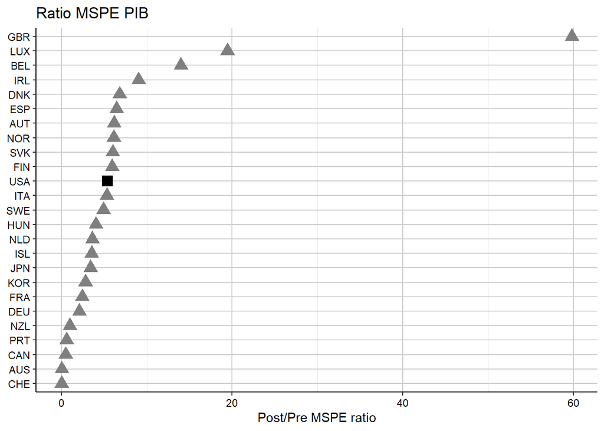

```r
tdf2 <- generate.placebos(dp_pib.out,s_pib.out, Sigf.ipop = 2, strategy = "multiprocess")

mspe.plot(
  tdf2,
  discard.extreme = FALSE,
  mspe.limit = 20,
  plot.hist = FALSE,
  title = "Ratio MSPE PIB",
  xlab = "Post/Pre MSPE ratio",
  ylab = NULL
)
```

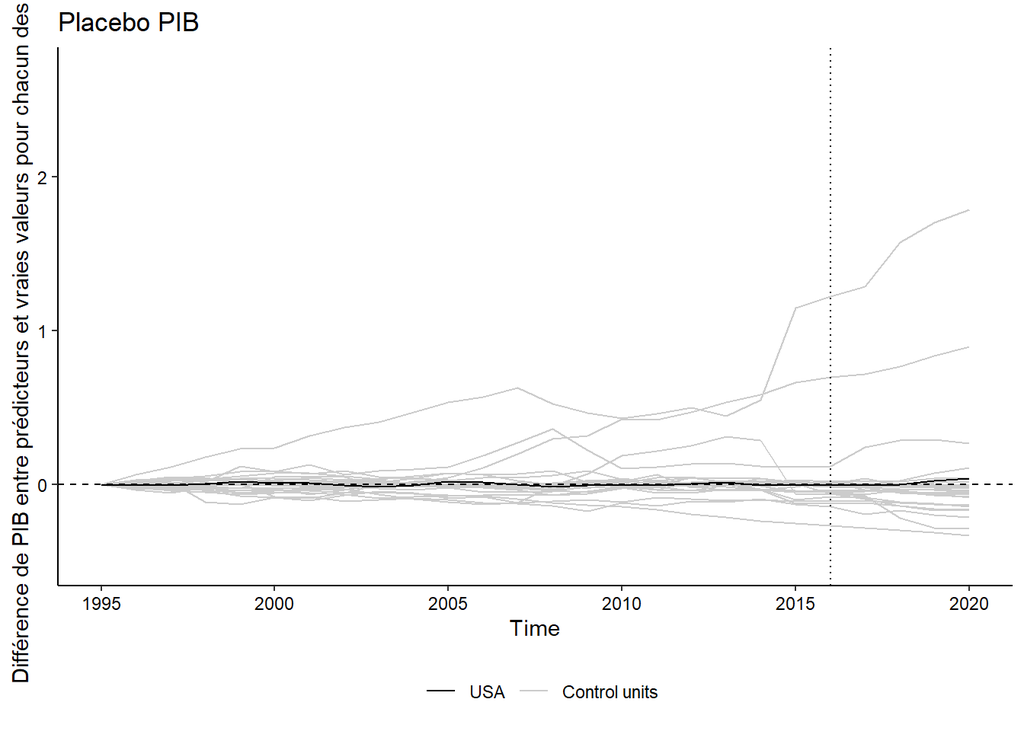

```r
ratio2 <- mspe.test(tdf2)

plot_placebos(
  tdf = tdf2,
  discard.extreme = FALSE,
  mspe.limit = 20,
  xlab = 'Time',
  ylab = 'Différence de PIB entre prédicteurs et vraies valeurs pour chacun des pays',
  title = "Placebo PIB",
  alpha.placebos = 1,
)
```

```r
ratio2$p.val
```

```
## [1] 0.44
```

##Modèle sans série temporelle

Modèle n’utilisant que la moyenne de chacune des variables sur l’ensemble de la période et prenant comme outcome le taux de chômage.

```r
dp_moy.out <- dataprep(
  foo = data,
  predictors = c("PIB", "Emplois", "Actifs", "Chomage", "Conso_share", "Invest_share", 'NExport_share', 'Labor_prod'),
  predictors.op = "mean",
  time.predictors.prior = 1995.00:2016.50,
  special.predictors = NULL,
  dependent = "Chomage",
  unit.variable = "ID_country",
  unit.names.variable = "LOCATION",
  time.variable = "TIME",
  treatment.identifier = 25,
  controls.identifier = 1:24,
  time.optimize.ssr = 1995.00:2016.50,
  time.plot = 1995.00:2020.00)
```

```r
s_moy.tables <- synth.tab(dataprep.res = dp_moy.out, synth.res = s_moy.out)
gaps_moy <- dp_moy.out$Y1plot - (dp_moy.out$Y0plot %*% s_moy.out$solution.w)

s_moy.tables$tab.pred
```

```
##               Treated Synthetic Sample Mean
## PIB             0.361     0.361       0.364
## Emplois         0.112     0.106       0.135
## Actifs          0.118     0.094       0.117
## Chomage         5.932     5.940       7.239
## Conso_share     0.669     0.616       0.534
## Invest_share    0.211     0.203       0.226
## NExport_share  -0.034    -0.017       0.038
## Labor_prod      0.001     0.001       0.003
```

```r
s_moy.tables$tab.v
```

```
##               v.weights
## PIB           0.303
## Emplois       0
## Actifs        0
## Chomage       0.541
## Conso_share   0.003
## Invest_share  0.002
## NExport_share 0
## Labor_prod    0.15
```

```r
s_moy.tables$tab.w
```

```
##    w.weights unit.names unit.numbers
## 1      0.000        AUS            1
## 2      0.000        AUT            2
## 3      0.000        BEL            3
## 4      0.000        CAN            4
## 5      0.000        CHE            5
## 6      0.000        DEU            6
## 7      0.000        DNK            7
## 8      0.000        ESP            8
## 9      0.000        FIN            9
## 10     0.000        FRA           10
## 11     0.441        GBR           11
## 12     0.000        HUN           12
## 13     0.000        IRL           13
## 14     0.262        ISL           14
## 15     0.000        ITA           15
## 16     0.048        JPN           16
## 17     0.050        KOR           17
## 18     0.000        LUX           18
## 19     0.000        NLD           19
## 20     0.000        NOR           20
## 21     0.000        NZL           21
## 22     0.199        PRT           22
## 23     0.000        SVK           23
## 24     0.000        SWE           24
```

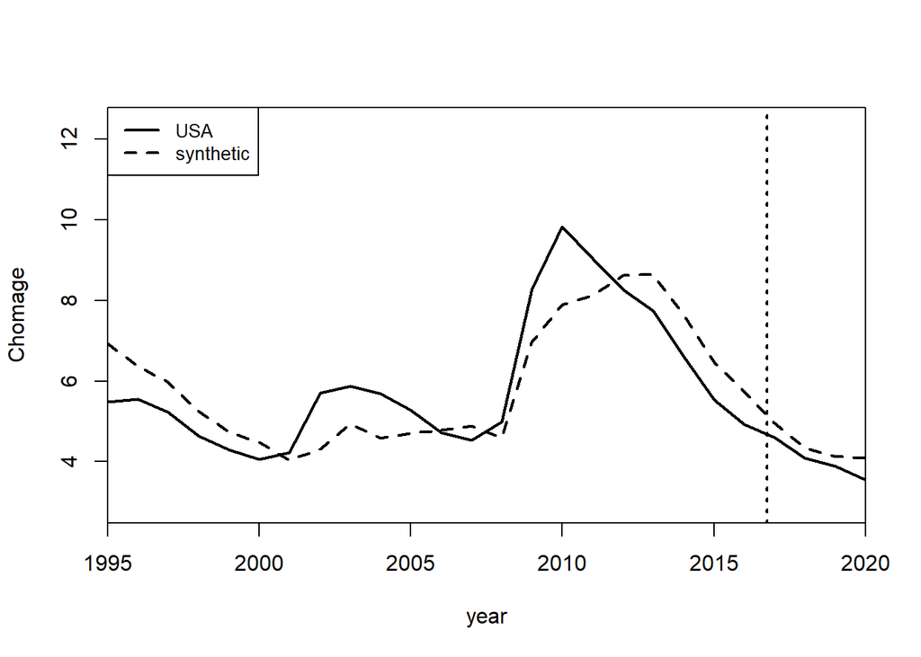

```r
path.plot(synth.res = s_moy.out, dataprep.res = dp_moy.out, Ylab = "Chomage", Xlab = "year", tr.intake = 2016.75, Legend = c("USA", "synthetic"), Legend.position = "topleft")
```

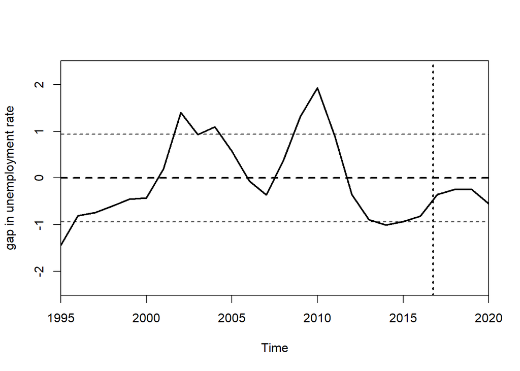

```r
gaps.plot(synth.res = s_moy.out, dataprep.res = dp_moy.out, Ylab = "gap in unemployment rate", tr.intake = 2016.75, Main = NA)
abline(h = sd(gaps_moy[1:22]), col="black", lwd=1, lty=2)
abline(h = -sd(gaps_moy[1:22]), col="black", lwd=1, lty=2)
```

```r
dp_moy2.out <- dataprep(
  foo = data,
  predictors = c("PIB", "Emplois", "Actifs", "Chomage", "Conso_share", "Invest_share", 'NExport_share', 'Labor_prod'),
  predictors.op = "mean",
  time.predictors.prior = 1995.00:2016.50,
  special.predictors = NULL,
  dependent = "PIB",
  unit.variable = "ID_country",
  unit.names.variable = "LOCATION",
  time.variable = "TIME",
  treatment.identifier = 25,
  controls.identifier = 1:24,
  time.optimize.ssr = 1995.00:2016.50,
  time.plot = 1995.00:2020.00)
```

```r
s_moy2.tables <- synth.tab(dataprep.res = dp_moy2.out, synth.res = s_moy2.out)
gaps_moy2 <- dp_moy2.out$Y1plot - (dp_moy2.out$Y0plot %*% s_moy2.out$solution.w)

s_moy2.tables$tab.pred
```

```
##               Treated Synthetic Sample Mean
## PIB             0.361     0.359       0.364
## Emplois         0.112     0.135       0.135
## Actifs          0.118     0.112       0.117
## Chomage         5.932     6.480       7.239
## Conso_share     0.669     0.626       0.534
## Invest_share    0.211     0.206       0.226
## NExport_share  -0.034    -0.019       0.038
## Labor_prod      0.001     0.003       0.003
```

```r
s_moy2.tables$tab.v
```

```
##               v.weights
## PIB           0.763
## Emplois       0.013
## Actifs        0.105
## Chomage       0.033
## Conso_share   0.044
## Invest_share  0.028
## NExport_share 0.004
## Labor_prod    0.01
```

```r
s_moy2.tables$tab.w
```

```
##    w.weights unit.names unit.numbers
## 1      0.249        AUS            1
## 2      0.000        AUT            2
## 3      0.000        BEL            3
## 4      0.000        CAN            4
## 5      0.000        CHE            5
## 6      0.000        DEU            6
## 7      0.000        DNK            7
## 8      0.000        ESP            8
## 9      0.000        FIN            9
## 10     0.000        FRA           10
## 11     0.543        GBR           11
## 12     0.000        HUN           12
## 13     0.000        IRL           13
## 14     0.028        ISL           14
## 15     0.000        ITA           15
## 16     0.000        JPN           16
## 17     0.031        KOR           17
## 18     0.000        LUX           18
## 19     0.000        NLD           19
## 20     0.000        NOR           20
## 21     0.000        NZL           21
## 22     0.149        PRT           22
## 23     0.000        SVK           23
## 24     0.000        SWE           24
```

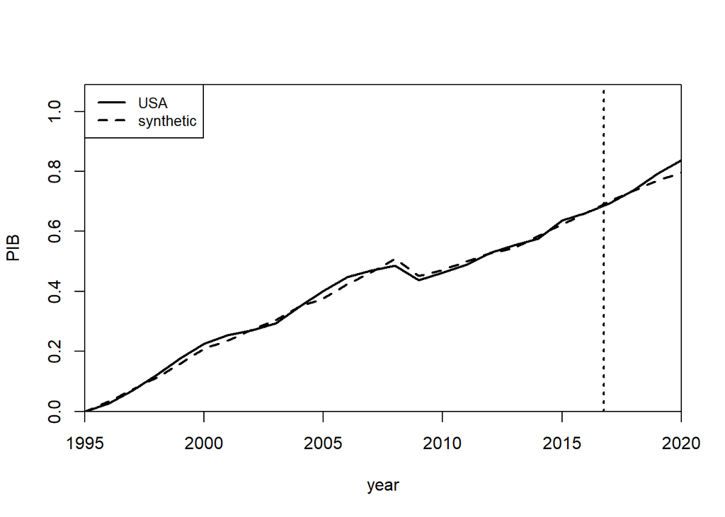

```r
path.plot(synth.res = s_moy2.out, dataprep.res = dp_moy2.out, Ylab = "PIB", Xlab = "year", tr.intake = 2016.75, Legend = c("USA", "synthetic"), Legend.position = "topleft")
```

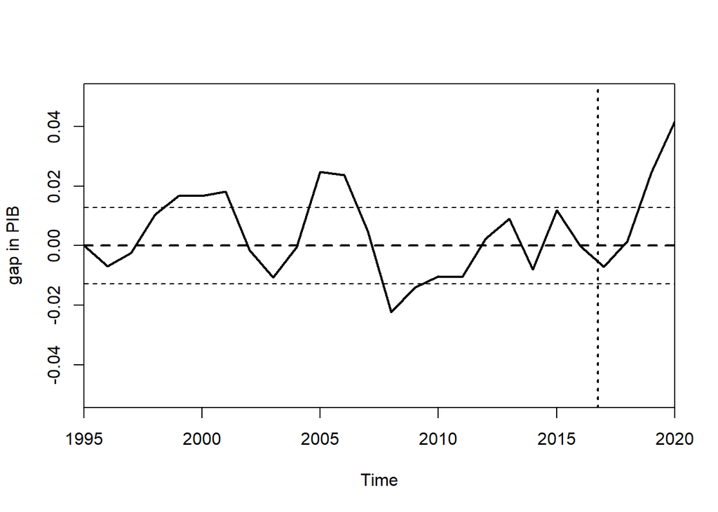

```r
gaps.plot(synth.res = s_moy2.out, dataprep.res = dp_moy2.out, Ylab = "gap in PIB", tr.intake = 2016.75, Main = NA)
abline(h = sd(gaps_moy2[1:22]), col="black", lwd=1, lty=2)
abline(h = -sd(gaps_moy2[1:22]), col="black", lwd=1, lty=2)
```

Comparaison des MSPE sur la période d’entraînement des différents modèles (issus du calcul de V et W): les modèles prenant le PIB comme outcome ont un meilleur MSPE (probablement parce que le PIB suit une tendance claire, contrairement au taux de chômage) mais on voit que aussi que l’ajout des séries temporelles permet d’améliorer le fit par rapport aux modèles n’utilisant que des moyennes.

```
## [1] "Loss V and W (modèle baseline): 0.5005"
```

```
## [1] "Loss V and W (modèle PIB): 1e-04"
```

```
## [1] "Loss V and W (modèle moyenne chômage): 0.8407"
```

```
## [1] "Loss V and W (modèle moyenne PIB): 2e-04"
```